# FE8828: Delta Hedging Assignment

Juilee Save <sub><Email: juilee001@e.ntu.edu.sg></sub> Toh Zhao Zhi <sub><Email: tohz0016pg@e.ntu.edu.sg></sub> Toh Jia Yuan <sub><Email: jtoh008pg@e.ntu.edu.sg></sub> Zhou Xueming <sub><Email: zhou0301@e.ntu.edu.sg></sub>

### Max Drawdown Function

```r
#To calculate max drawdown in dollars
maxDD_Dollar = function(DailyPnL){
  PnL = cumsum(DailyPnL)
  mDD = 0

  for(i in 2:length(PnL)){
    M = max(PnL[1:i])
    DD = M - PnL[i]

    if(DD > mDD)
      mDD = DD
  }

  mDD
}

#To calculate max drawdown in % using gross returns
maxDD_Ret = function(DailyRet){
  Ret = cumprod(DailyRet+1)
  mDD = 0

  for(i in 2:length(Ret)){
    M = max(Ret[1:i])
    DD = M - Ret[i]

    if(DD > mDD)
      mDD = DD
  }

  mDD
}
```

### Read Data

```r
getwd()
```

```
## [1] "D:/gdrive/MFECourse/FE8828/2017/FE8828 Toh Zhao Zhi - RW/Group Project"
```

```r
data = read.csv("FBData.csv", sep=",", stringsAsFactors = FALSE) #Read stock and options data from csv file into dataframe
data.xts = xts(x = data[,-1, drop = F],order.by = as.Date(data[,1], "%d-%B-%y")) #Create xts object to store data from dataframe
dates = index(data.xts) #pick a date range using xts object
last_test_date = max(dates) - 29 #Hedge over 29 days for a 30day option
last_date_index = sum(dates <= last_test_date)
```

### Perform Analysis for one trade

#### Set details of Option

```r
start_date = dates[1]
end_date = start_date + 29 #hedging period is 29 days for a 30day option
start_price = as.numeric(data.xts[start_date,"Close"]) #current stock price
start_volatility = data.xts[start_date,"IV30"] #volatility
Strike = as.numeric(start_price) #strike price
vol = as.numeric(start_volatility)/100 #volatility
rf = 0.8/100 #risk-free rate
Q = 100 #quantity of options
```

#### Store Data in dataframe and Compute Option Price, Delta, and PnLs (stock, option and both)

```r
df = tibble(dates[dates<=end_date & dates>=start_date]) #Using tibble for better representation of the dataframe
names(df) = "Date"
df$Close = as.numeric(data.xts[paste0(start_date,"/",end_date), "Close"]) #using xts object to select dates


df %>% #mutate to add columns to dataframe df
  mutate(Time = as.numeric(end_date - Date)/365, #Time to expiry for option price calculation
         premium = GBSOption(TypeFlag = "c", S = Close, X = Strike, Time = Time, r = rf, b = 0, sigma = vol)@price, #Calculating call option price for stock without dividend
         delta = GBSGreeks("delta", TypeFlag = "c", S = Close, X = Strike, Time = Time, r = rf, b = 0, sigma = vol), #Calculating option delta
         Option_DoD_PnL = ifelse(Date == start_date, 0, Q*(premium - lag(premium))), #daily option PnL in dollars
         Option_DoD_Ret = ifelse(Date == start_date, 0, (premium - lag(premium))/lag(premium)), #daily option PnL expressed as returns
         Hedge_DoD_PnL = ifelse(Date == start_date | Date == end_date, 0, Q*lag(delta)*(lag(Close)-Close)), #daily hedging PnL in dollars
         Hedge_DoD_Ret = ifelse(Date == start_date | Date == end_date, 0, (lag(Close)-Close)/Close), #daily hedging PnL expressed as returns
         Daily_PnL = Option_DoD_PnL + Hedge_DoD_PnL, #total daily PnL in dollars
         Daily_Ret = ifelse(Date == start_date,0 ,Daily_PnL/(Close + lag(premium))) #total daily PnL expressed as returns
         ) -> df #
df
```

```
## # A tibble: 20 x 11
##          Date  Close        Time   premium     delta Option_DoD_PnL
##        <date>  <dbl>       <dbl>     <dbl>     <dbl>          <dbl>
##  1 2016-12-06 117.31 0.079452055 2.7549079 0.5114243       0.000000
##  2 2016-12-07 117.95 0.076712329 3.0462158 0.5485835      29.130797
##  3 2016-12-08 118.91 0.073972603 3.5516238 0.6048075      50.540798
##  4 2016-12-09 119.68 0.071232877 3.9869589 0.6500523      43.533506
##  5 2016-12-12 117.77 0.063013699 2.6953351 0.5398839    -129.162374
##  6 2016-12-13 120.31 0.060273973 4.2183576 0.6973598     152.302246
##  7 2016-12-14 120.21 0.057534247 4.0992625 0.6954209     -11.909503
##  8 2016-12-15 120.57 0.054794521 4.3042820 0.7203221      20.501948
##  9 2016-12-16 119.87 0.052054795 3.7614453 0.6828795     -54.283675
## 10 2016-12-19 119.24 0.043835616 3.1703432 0.6532748     -59.110205
## 11 2016-12-20 119.09 0.041095890 3.0116191 0.6465606     -15.872410
## 12 2016-12-21 119.04 0.038356164 2.9158112 0.6471310      -9.580794
## 13 2016-12-22 117.40 0.035616438 1.8913418 0.5154737    -102.446937
## 14 2016-12-23 117.27 0.032876712 1.7527289 0.5038363     -13.861285
## 15 2016-12-27 118.01 0.021917808 1.8287721 0.5821847       7.604316
## 16 2016-12-28 116.92 0.019178082 1.1660062 0.4598702     -66.276590
## 17 2016-12-29 116.35 0.016438356 0.8270490 0.3846141     -33.895723
## 18 2016-12-30 115.05 0.013698630 0.3444198 0.2167829     -48.262913
## 19 2017-01-03 116.86 0.002739726 0.3171943 0.3647170      -2.722557
## 20 2017-01-04 118.69 0.000000000 1.3800000 1.0000000     106.280573
## # ... with 5 more variables: Option_DoD_Ret <dbl>, Hedge_DoD_PnL <dbl>,
## #   Hedge_DoD_Ret <dbl>, Daily_PnL <dbl>, Daily_Ret <dbl>
```

#### Calculation of maxDD in Dollar Terms

```r
#summing daily PnL to get total PnL at the end of hedging duration
df %>% summarize(Option_PnL = sum(Option_DoD_PnL), Option_maxDD = maxDD_Dollar(Option_DoD_PnL), Stock_PnL = sum(Hedge_DoD_PnL), Stock_maxDD = maxDD_Dollar(Hedge_DoD_PnL), PnL = sum(Daily_PnL), maxDrawDown = maxDD_Dollar(Daily_PnL))
```

```
## # A tibble: 1 x 6
##   Option_PnL Option_maxDD Stock_PnL Stock_maxDD       PnL maxDrawDown
##        <dbl>        <dbl>     <dbl>       <dbl>     <dbl>       <dbl>
## 1  -137.4908     398.7088  119.4581    162.9974 -18.03272    125.7224
```

#### Calculation of Sharpe Ratio

```r
#Calcuating Sharpe ratio using returns
df %>% summarize(Option_Sharpe = (mean(Option_DoD_Ret)-exp(rf/365)+1)/sd(Option_DoD_Ret), Stock_Sharpe = (mean(Hedge_DoD_Ret) - exp(rf/365)+1)/sd(Hedge_DoD_Ret), Sharpe = (mean(Daily_Ret) - exp(rf/365)+1)/sd(Daily_Ret))
```

```
## # A tibble: 1 x 3
##   Option_Sharpe Stock_Sharpe      Sharpe
##           <dbl>        <dbl>       <dbl>
## 1      0.121097   0.02278714 -0.03120404
```

#### Plot of Daily PnL

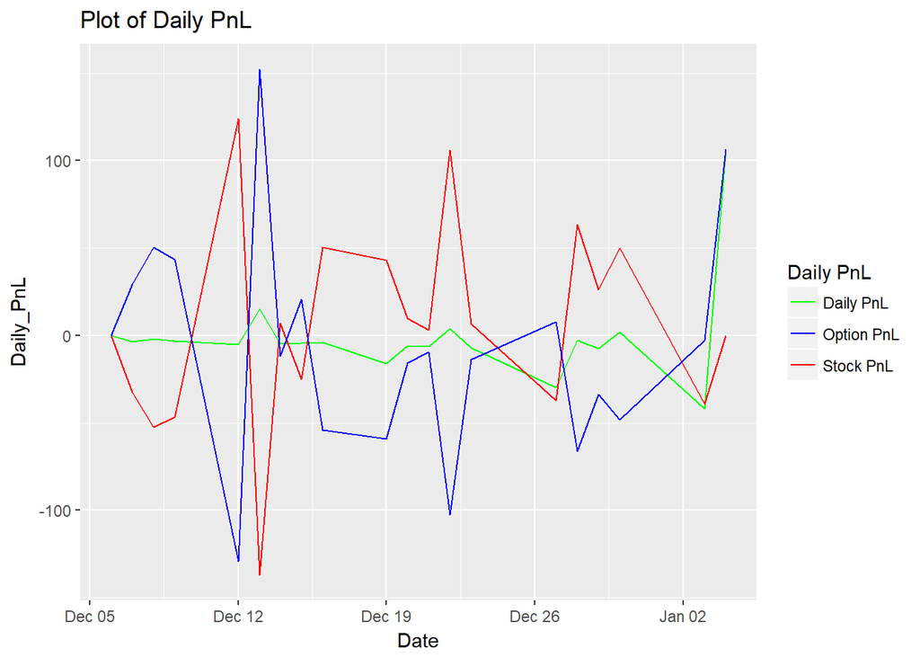

```r
#Using line graphs to track the movements of stock, option and total daily PnL over time
ggplot(df) + geom_line(aes(Date,Daily_PnL, color = "Daily PnL")) + geom_line(aes(Date, Hedge_DoD_PnL, color = "Stock PnL")) + geom_line(aes(Date, Option_DoD_PnL, color = "Option PnL")) + ggtitle("Plot of Daily PnL") +   scale_color_manual(name = "Daily PnL", values = c("Daily PnL" = "green", "Stock PnL"="red", "Option PnL"="blue"))
```

From the plots, we see that stock PnL and option PnL are volatile and move in opposite directions. Delta hedging reduces risk associated with price movement of the underlying stock. The daily PnL hovers around 0.

#### Plot of Cumulative PnL

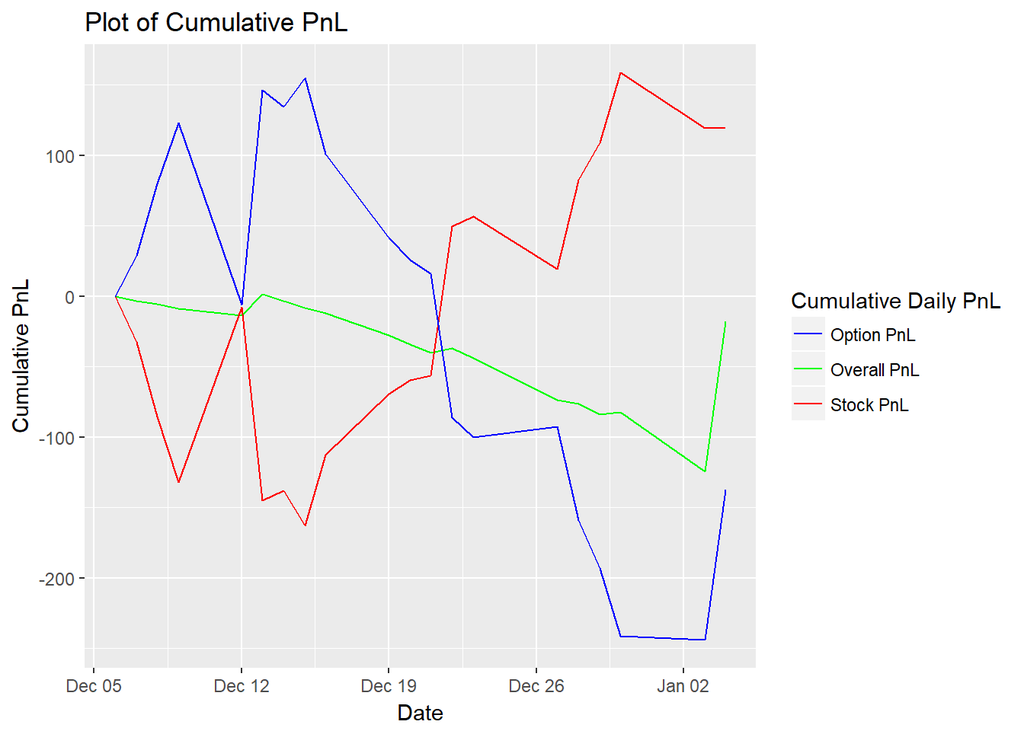

```r
#cumsum returns the cumulative sum of PnL from day 1 to current day
df %>% mutate(cum_Option_PnL = cumsum(Option_DoD_PnL), cum_Stock_PnL = cumsum(Hedge_DoD_PnL), cum_PnL = cumsum(Daily_PnL)) -> df2

#to track total cumulative PnL over time
ggplot(df2) +geom_line(aes(Date,cum_PnL, color = "Overall PnL")) + geom_line(aes(Date, cum_Stock_PnL, color = "Stock PnL")) + geom_line(aes(Date, cum_Option_PnL, color = "Option PnL")) + ggtitle("Plot of Cumulative PnL") +   scale_color_manual(name = "Cumulative Daily PnL", values = c("Overall PnL" = "green", "Stock PnL"="red", "Option PnL"="blue")) + ylab("Cumulative PnL")
```

From the cumulative PnL plot, we observe that although delta hedging reduces the volatility in total PnL, the hedge is not perfect. While fluctation in PnL is reduced, the cumulative PnL tends to the negative region. This is because perfect delta hedging requires continuous-time rebalancing. Therefore in reality, a delta-neutral portfolio is only immunized against small changes in stock price. Furthermore, one limitation of this exercise is that option price and delta are calculated assuming that volatility is constant (using implied volatility on the first day).

#### Final PnL

```r
df2 %>%select(cum_PnL, cum_Stock_PnL, cum_Option_PnL) -> Final_PnL_df
Final_PnL_df[nrow(Final_PnL_df),]
```

```
## # A tibble: 1 x 3
##     cum_PnL cum_Stock_PnL cum_Option_PnL
##       <dbl>         <dbl>          <dbl>
## 1 -18.03272      119.4581      -137.4908
```

### Generate Backtest Results

```r
#Using a for loop to backtest the remaining days of the data
BackTestResult = data.frame(StartDate = character(0),FinalPnL = numeric(0), StockPnL = numeric(0), OptionPnL = numeric(0),maxDrawDown = numeric(0), OverallSharpe = numeric(0), StockSharpe = numeric(0), OptionSharpe = numeric(0), stringsAsFactors = FALSE) #generate
for(i in 1:last_date_index){
  #Set details of Option
  start_date = dates[i]
  end_date = start_date + 29
  start_price = as.numeric(data.xts[start_date,"Close"])
  start_volatility = data.xts[start_date,"IV30"]
  Strike = as.numeric(start_price)
  vol = as.numeric(start_volatility)/100
  rf = 0.8/100
  Q = 100

  df.bt = tibble(dates[dates<=end_date & dates>=start_date]) #for nicer representation of dataframe
  names(df.bt) = "Date"
  df.bt$Close = as.numeric(data.xts[paste0(start_date,"/",end_date), "Close"])

  #Compute Option Price, Delta, and PnLs (stock, option and both)
  df.bt %>% #Similar to df, df.bt stores prices, delta and PnLs after computation
    mutate(Time = as.numeric(end_date - Date)/365,
           premium = GBSOption(TypeFlag = "c", S = Close, X = Strike, Time = Time, r = rf, b = 0, sigma = vol)@price,
           delta = GBSGreeks("delta", TypeFlag = "c", S = Close, X = Strike, Time = Time, r = rf, b = 0, sigma = vol),
           Option_DoD_PnL = ifelse(Date == start_date, 0, Q*(premium - lag(premium))),
           Option_DoD_Ret = ifelse(Date == start_date, 0, (premium - lag(premium))/lag(premium)),
           Hedge_DoD_PnL = ifelse(Date == start_date | Date == end_date, 0, Q*lag(delta)*(lag(Close)-Close)),
           Hedge_DoD_Ret = ifelse(Date == start_date | Date == end_date, 0, (lag(Close)-Close)/Close),
           Daily_PnL = Option_DoD_PnL + Hedge_DoD_PnL,
           Daily_Ret = ifelse(Date == start_date,0 ,Daily_PnL/(Close + lag(premium)))
    ) -> df.bt
  df.bt

  #Calculation of maxDD in Dollar Terms
  df.bt %>% summarize(Option_PnL = sum(Option_DoD_PnL), Option_maxDD = maxDD_Dollar(Option_DoD_PnL), Stock_PnL = sum(Hedge_DoD_PnL), Stock_maxDD = maxDD_Dollar(Hedge_DoD_PnL), PnL = sum(Daily_PnL), maxDrawDown = maxDD_Dollar(Daily_PnL)) -> maxDD.bt

  #Calculation of Sharpe Ratio
  df.bt %>% summarize(Option_Sharpe = (mean(Option_DoD_Ret)-exp(rf/365)+1)/sd(Option_DoD_Ret), Stock_Sharpe = (mean(Hedge_DoD_Ret) - exp(rf/365)+1)/sd(Hedge_DoD_Ret), Sharpe = (mean(Daily_Ret) - exp(rf/365)+1)/sd(Daily_Ret)) ->Sharpe.bt

  #Plot of Cumulative PnL
  df.bt %>% mutate(cum_Option_PnL = cumsum(Option_DoD_PnL), cum_Stock_PnL = cumsum(Hedge_DoD_PnL), cum_PnL = cumsum(Daily_PnL)) %>% filter(row_number() == n()) -> PnL.bt

  #Appending backtesting data to dataframe
  BackTestResult = add_row(BackTestResult, StartDate = as.character(start_date), FinalPnL = PnL.bt$cum_PnL[1], StockPnL = PnL.bt$cum_Stock_PnL[1], OptionPnL = PnL.bt$cum_Option_PnL[1], maxDrawDown = maxDD.bt$maxDrawDown[1], OverallSharpe = Sharpe.bt$Sharpe, StockSharpe = Sharpe.bt$Stock_Sharpe, OptionSharpe = Sharpe.bt$Option_Sharpe)
  }

BackTestResult
```

```
##      StartDate     FinalPnL      StockPnL   OptionPnL maxDrawDown
## 1   2016-12-06  -18.0327213   119.4580645 -137.490786   125.72238
## 2   2016-12-07   84.2928007    87.9616162   -3.668816   112.22079
## 3   2016-12-08  216.0906236    41.3316427  174.758981    98.36273
## 4   2016-12-09    5.3302050  -101.4487142  106.778919    81.68915
## 5   2016-12-12 -105.6644271  -465.9273572  360.262930   117.60163
## 6   2016-12-13  126.2676858  -151.6279185  277.895604    89.30510
## 7   2016-12-14    0.7878374  -333.6060106  334.393848    86.58384
## 8   2016-12-15  133.3562985  -346.9536775  480.309976    72.42059
## 9   2016-12-16  -35.5059633  -588.8663415  553.360378    69.93492
## 10  2016-12-19  -60.7733736  -645.0896130  584.316239    60.77337
## 11  2016-12-20   -1.8646536  -610.5447569  608.680103    41.38880
## 12  2016-12-21  -35.9735386  -618.1176970  582.144158    40.45667
## 13  2016-12-22  -73.3449891  -744.4993732  671.154384    73.34499
## 14  2016-12-23  -12.9405529  -705.3012912  692.360738    38.01925
```

[output cut: 453 more lines]

### Analysis of Results from Backtesting

#### Final PnL Distribution

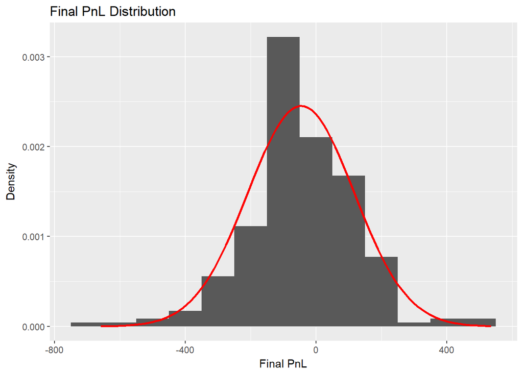

```r
ggplot(data = BackTestResult, aes(FinalPnL)) + geom_histogram(binwidth = 100, aes(y = ..density..)) +  stat_function(fun = dnorm,
                args = list(mean = mean(BackTestResult$FinalPnL), sd = sd(BackTestResult$FinalPnL)),
                lwd = 1,
                col = 'red') +
  xlab("Final PnL") + ylab("Density") + ggtitle("Final PnL Distribution")
```

Backtesting results show that total PnL has a mean of 0, concurring with our earlier findings using the data set of the first 29 days.

#### PnLs Distributions

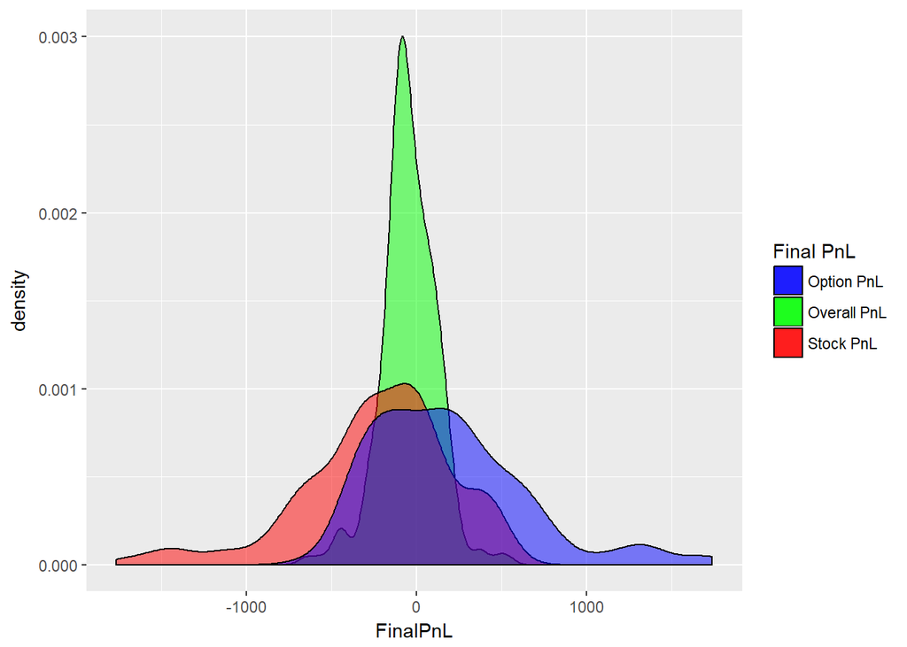

```r
ggplot(data = BackTestResult) + geom_density(aes(FinalPnL, fill = "Overall PnL"), alpha = 0.5) + geom_density(aes(StockPnL, fill = "Stock PnL"), alpha = 0.5) + geom_density(aes(OptionPnL, fill = "Option PnL"), alpha = 0.5) + scale_fill_manual(name = "Final PnL", values = c("Overall PnL" = "green", "Stock PnL"="red", "Option PnL"="blue"))
```

For distributions of all 3 PnLs, the mean is 0. However, it can be observed that the total PnL has the smallest standard deviation, with data tightly clustered around the mean. This agrees with the rationale of delta hedging, which is to reduce volatility of total PnL.

#### Sharpe Distributions

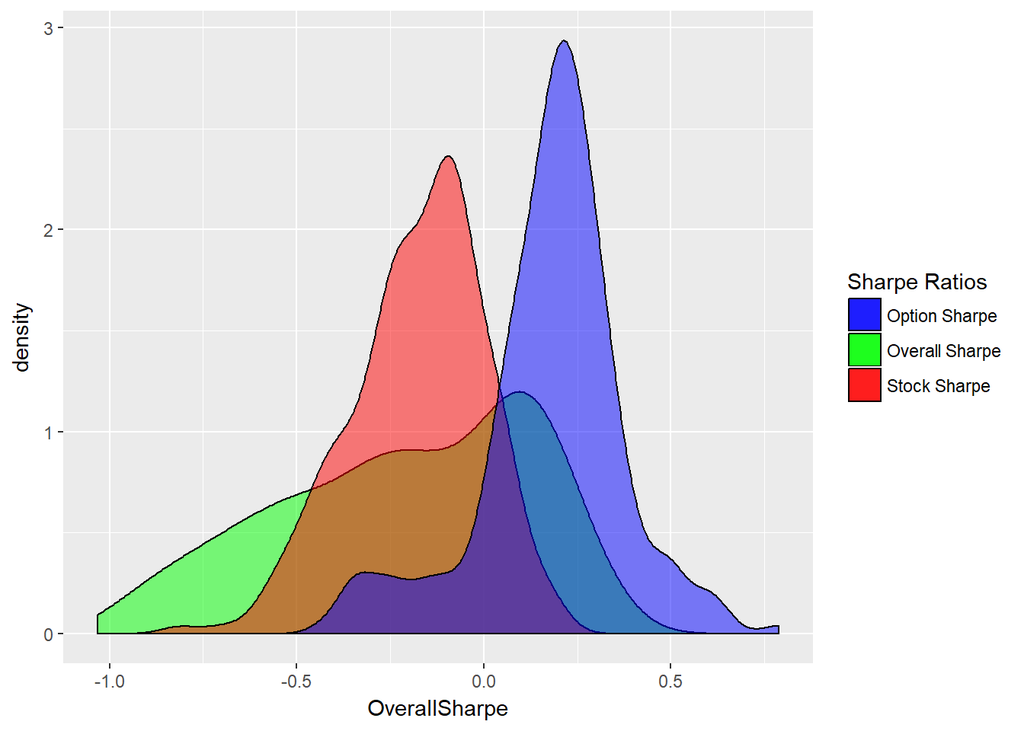

```r
ggplot(data = BackTestResult) + geom_density(aes(OverallSharpe, fill = "Overall Sharpe"), alpha = 0.5) + geom_density(aes(StockSharpe, fill = "Stock Sharpe"), alpha = 0.5) + geom_density(aes(OptionSharpe, fill = "Option Sharpe"), alpha = 0.5) + scale_fill_manual(name = "Sharpe Ratios", values = c("Overall Sharpe" = "green", "Stock Sharpe"="red", "Option Sharpe"="blue"))
```

#### Max Drawdown Distribution

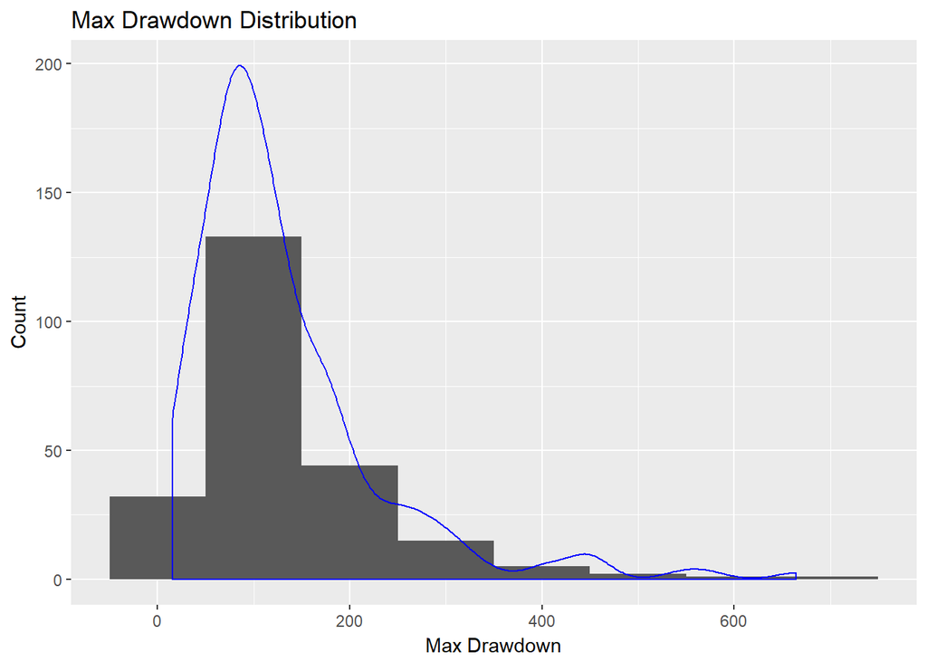

```r
ggplot(data = BackTestResult, aes(maxDrawDown)) + geom_histogram(binwidth = 100) + geom_density(aes(y = ..density..*30000), color = "blue") + ggtitle("Max Drawdown Distribution") + xlab("Max Drawdown") + ylab("Count")
```

#### Final PnL Against Option Expiry Date

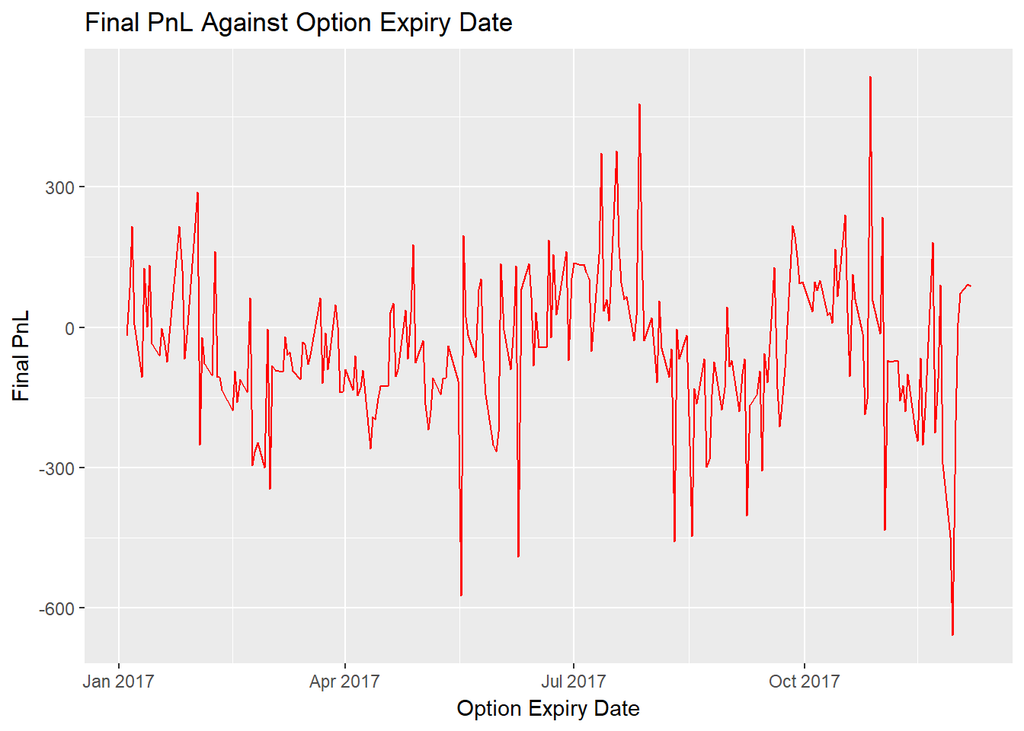

```r
 ggplot(BackTestResult) + geom_line(aes(as.Date(StartDate)+29,FinalPnL), color = "red") + xlab("Option Expiry Date") + ylab("Final PnL") + ggtitle("Final PnL Against Option Expiry Date")
```

We see that final PnL does not vary significantly with option expiry dates (except for the last segment of the graph.)